# Read in the dataset and process the data

Let us look at the data types. Convert the date to Date object and look at the data types

```r
setwd ('/home/kirana/coursera/researchmethods')
library (data.table)
activity <- fread ('activity.csv', header=T)
print (str(activity))
```

```
## Classes 'data.table' and 'data.frame':   17568 obs. of  3 variables:
##  $ steps   : int  NA NA NA NA NA NA NA NA NA NA ...
##  $ date    : chr  "2012-10-01" "2012-10-01" "2012-10-01" "2012-10-01" ...
##  $ interval: int  0 5 10 15 20 25 30 35 40 45 ...
##  - attr(*, ".internal.selfref")=<externalptr>
## NULL
```

```r
activity [,date := as.Date (date, format = "%Y-%m-%d")]
print (str(activity))
```

```
## Classes 'data.table' and 'data.frame':   17568 obs. of  3 variables:
##  $ steps   : int  NA NA NA NA NA NA NA NA NA NA ...
##  $ date    : Date, format: "2012-10-01" "2012-10-01" ...
##  $ interval: int  0 5 10 15 20 25 30 35 40 45 ...
##  - attr(*, ".internal.selfref")=<externalptr>
## NULL
```

# Histogram of the total number of steps taken each day

We have to sum the number of steps per day

```r
activity1 <- activity [,list (steps= sum(steps)),by=date]
temp <- copy (activity1)
print ("Overall Mean")
```

```
## [1] "Overall Mean"
```

```r
meanperday <- mean (temp$steps, na.rm=TRUE)
print (meanperday)
```

```
## [1] 10766.19
```

```r
print ("Overall Median")
```

```
## [1] "Overall Median"
```

```r
medianperday <- median (temp$steps, na.rm=TRUE)
print (medianperday)
```

```
## [1] 10765
```

We just use the ggplot2 library and call the histogram function. We could have also used qplot or the base histogram function

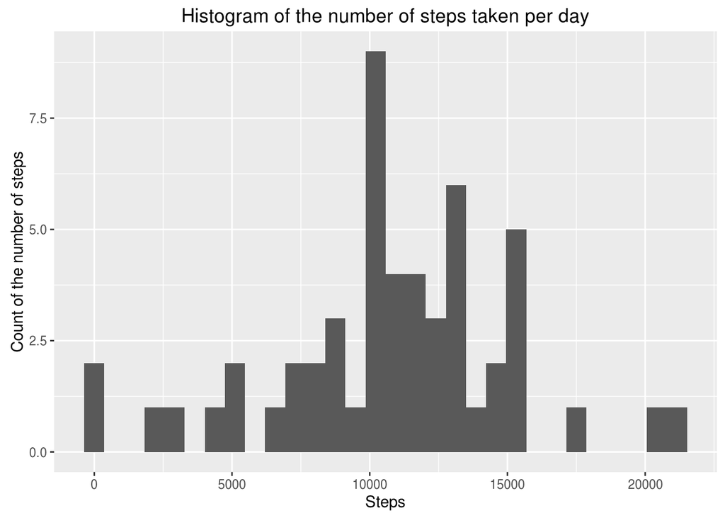

```r
library (ggplot2)
ggplot (activity1, aes (x=steps)) + geom_histogram () + ggtitle ("Histogram of the number of steps taken per day") + xlab ("Steps") + ylab ("Count of the number of steps")
```

# Mean and median number of steps per day

```r
temp <- activity [,list (meanperday = mean(steps*1.0, na.rm=TRUE),
medianperday = median (steps*1.0, na.rm=TRUE)),by=date]
print (temp)
```

```
##           date meanperday medianperday
##  1: 2012-10-01        NaN           NA
##  2: 2012-10-02  0.4375000            0
##  3: 2012-10-03 39.4166667            0
##  4: 2012-10-04 42.0694444            0
##  5: 2012-10-05 46.1597222            0
##  6: 2012-10-06 53.5416667            0
##  7: 2012-10-07 38.2465278            0
##  8: 2012-10-08        NaN           NA
##  9: 2012-10-09 44.4826389            0
## 10: 2012-10-10 34.3750000            0
## 11: 2012-10-11 35.7777778            0
## 12: 2012-10-12 60.3541667            0
## 13: 2012-10-13 43.1458333            0
## 14: 2012-10-14 52.4236111            0
```

[output cut: 48 more lines]

# Time series plot of the average number of steps taken

We just use ggplot2 library function to accomplish this

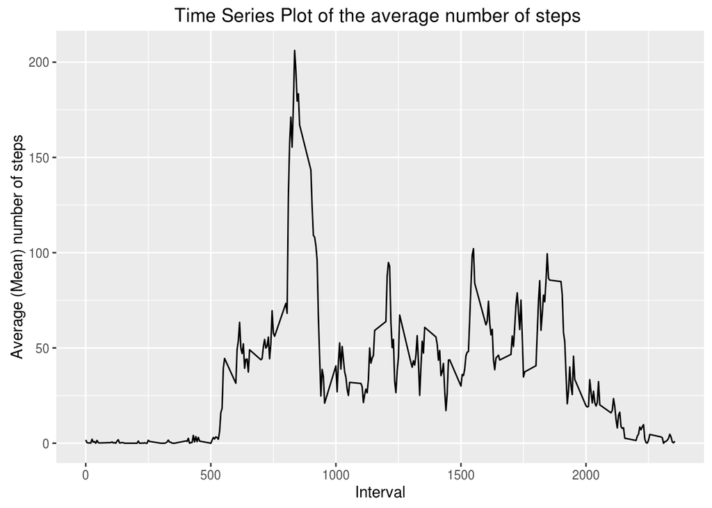

```r
temp <- activity [,list (meanperday = mean(steps, na.rm=TRUE)),by=interval]

ggplot (temp, aes (interval, meanperday)) + geom_line () + ggtitle ("Time Series Plot of the average number of steps ") + xlab ("Interval") + ylab ("Average (Mean) number of steps")
```

# The 5 minute interval that on an average contains the maximum number of steps

```r
fiveminmax <- activity [,list(steps = mean(steps, na.rm=TRUE)),by = interval]
fiveminmax <- fiveminmax [order(steps, decreasing=TRUE),]
print ("5 minute interval that on an average contains the maximum number of steps is")
```

```
## [1] "5 minute interval that on an average contains the maximum number of steps is"
```

```r
print (fiveminmax[1,interval])
```

```
## [1] 835
```

# Code to describe and show a strategy for imputing missing data

We will replace the missing values with the mean

```r
means <- activity [,list (meansteps  = mean(steps, na.rm=TRUE)), by = interval]
imputeactivity <- merge (activity, means, by= "interval", all.x=TRUE)
imputeactivity [,steps := ifelse (is.na(steps), meansteps, steps)]
print ('Let us now compare the %age missing values in each variable before and after imputation')
```

```
## [1] "Let us now compare the %age missing values in each variable before and after imputation"
```

```r
    print ('Before imputation')
```

```
## [1] "Before imputation"
```

```r
print (activity [,lapply(.SD, function(x) length(which(is.na(x))))])
```

```
##    steps date interval
## 1:  2304    0        0
```

```r
    print ('After imputation')
```

```
## [1] "After imputation"
```

```r
print (imputeactivity [,lapply(.SD, function(x) length(which(is.na(x))))])
```

```
##    interval steps date meansteps
## 1:        0     0    0         0
```

# Histogram of the total number of steps taken each day after missing values are imputed

We just use the ggplot2 library and call the histogram function. We could have also used qplot or the base histogram function

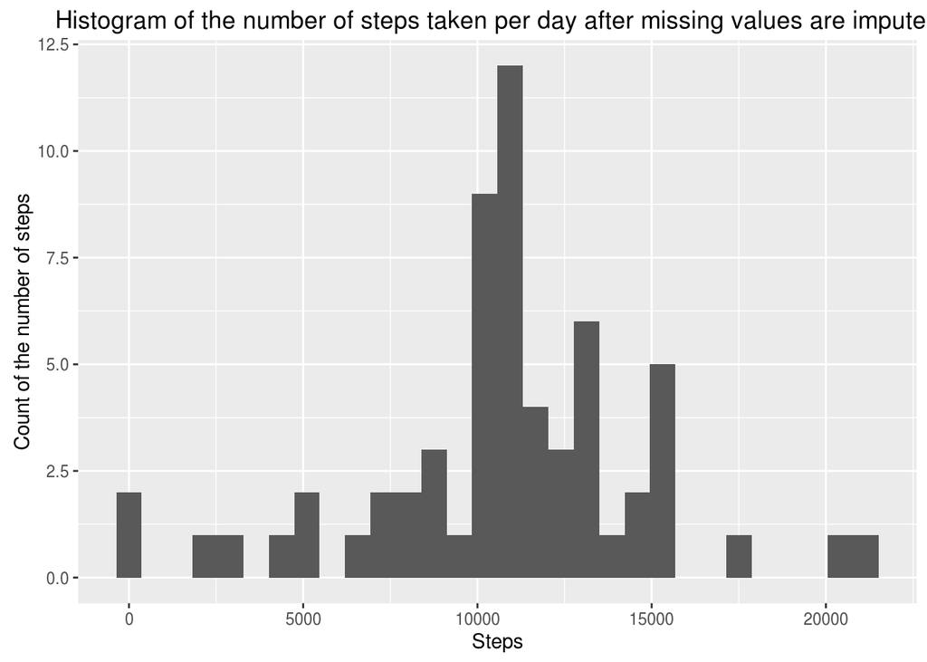

```r
library (ggplot2)
imputeactivity1 <- imputeactivity [,list(steps=sum(steps)), by=date]
ggplot (imputeactivity1, aes (x=steps)) + geom_histogram () + ggtitle ("Histogram of the number of steps taken per day after missing values are imputed") + xlab ("Steps") + ylab ("Count of the number of steps")
```

```r
print ("Overall Mean")
```

```
## [1] "Overall Mean"
```

```r
temp <- copy (imputeactivity1)
meanperday <- mean (temp$steps, na.rm=TRUE)
print (meanperday)
```

```
## [1] 10766.19
```

```r
print ("Overall Median")
```

```
## [1] "Overall Median"
```

```r
medianperday <- median (temp$steps, na.rm=TRUE)
print (medianperday)
```

```
## [1] 10766.19
```

By comparing the histogram of the new dataset with the imputed values with the histogram of the original dataset with the missing values above, we can see that the values do differ slightly

# Panel plot comparing the average number of steps taken per 5-minute interval across weekdays and weekends

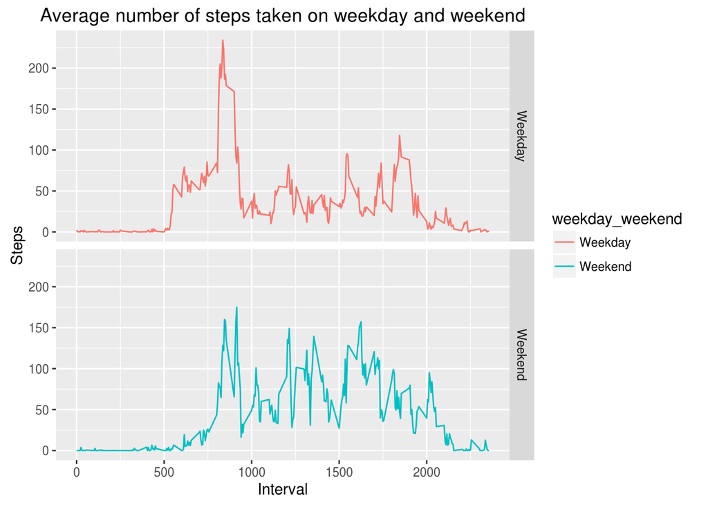

```r
activity [,dayofweek := wday (date)]
activity [,weekday_weekend := ifelse (dayofweek == 1, "Weekend", "Weekday")]
activity [,weekday_weekend := ifelse (dayofweek == 7, "Weekend", weekday_weekend)]


tempnew <- activity [,list (steps = mean(steps, na.rm=TRUE)),by = list (weekday_weekend, interval)]
ggplot (tempnew, aes (y=steps, x=interval, color = weekday_weekend)) + geom_line () + ggtitle ("Average number of steps taken on weekday and weekend")  + xlab ("Interval") + ylab ("Steps") + facet_grid (weekday_weekend ~ .)
```